# Lab 8: One-sample and Paired Samples *t*-tests

You can download the .Rmd file here.

Unquote the following install line to install the papaja package, which is used for preparaing APA style reports.

```r
# install.packages("papaja")
library(papaja) # for reporting results
```

Today’s lab will guide you through the process of conducting a One-Sample *t*-test and a Paired Samples *t*-test.

To quickly navigate to the desired section, click one of the following links:

1. One-Sample *t*-test
2. Paired Samples *t*-test
3. Minihacks

As always, there are minihacks to test your knowledge.

# One-Sample *t*-test

## The Data

In our first example, we will be analyzing data from Fox and Guyer’s (1978) anonymity and cooperation study. The data is included in the `{carData}` package and you can see information about the data set using `?Guyer`. Twenty groups of four participants each played 30 trials of the the prisoner’s dilemma game. The number of cooperative choices (`cooperation`) made by each group were scored out of 120 (i.e., cooperative choices made by 4 participants over 30 trials).

Run the following code to load the data into your global environment.

```r
#install.packages('carData') #if you need to install this package
# load data
library(carData) # includes the Guyer data set
data <- Guyer
```

## What is a One-Sample *t*-test?

A One-Sample *t*-test tests whether an obtained sample mean came from a population with a known mean. Let’s consider the cooperation data form `Guyer`. We might be interested in whether people cooperate more or less than 50% of the time. If people cooperate 50% of the time, then out of the 120 trials, we would expect people to have chosen to cooperate 60 times. Let’s compare our actual results (our sample mean) to the mean we would expect if our sample was obtained from a population with a mean of 60.

**Question:** How does this differ from a Z-test?

**Question:** What are our null and alternative hypotheses?

**Question:** What are our assumptions?

**Question:** What kind of sampling distribution do we have? What does it represent?

**Question:** How do we calculate our test statistic? What does it represent?

## A One-Sample *t*-test

### The null and alternative hypotheses

The null hypothesis states that..

$$H_{0}: \mu = 60$$

The alternative hypothesis states that..

$$H_{1}: \mu \neq 60$$

### Assumptions

The assumptions include..

1. *Normality*: Assume that the population distribution is normally distributed.
2. *Independence*: Assume that the observations are independent of one another.

### Sampling Distribution of Means

For a one-sample t-test, the sampling distribution is a *t* distribution. It represents all the possible sample means we could expect to obtain if we randomly obtained a sample of size *n* from the population that is described by the null hypothesis.

### The One-Sample t-Statistic

$$t = \frac{\bar X - \mu}{\hat \sigma /
\sqrt{N}}$$
The t-statistic is calculated by calculating the difference between the sample mean and the population mean predicted by the null hypothesis, divided by the estimated standard error. In other words, this statistic tells us how far away our sample mean is from the mean of our sampling distribution (which describes what we expect to find *if the null hypothesis is true*), in standard error units.

Use R to calculate the t-statistic for this example “from scratch”:

```r
#your code here:

t_stat <- (mean(data$cooperation) - 60) / (sd(data$cooperation) / sqrt(length(data$cooperation)))
t_stat
```

```
## [1] -3.662373
```

```r
#p value
pt(q = abs(t_stat), df = length(data$cooperation)-1, lower.tail = FALSE) * 2
```

```
## [1] 0.001655805
```

## Conducting the One-Sample t-Test in R

There are two useful functions for conducting a one-sample *t*-test in R. The first, is called `t.test()` and it is automatically loaded as part of the `{stats}` package when you first open R. To run a one-sample *t*-test using `t.test()`, you provide the function the column of the data you are interested in (e.g., `x = data$cooperation`) and the mean value you want to compare the data against (e.g., `mu = 60`).

```r
t.test(x = data$cooperation, mu = 60)
```

```
##
##  One Sample t-test
##
## data:  data$cooperation
## t = -3.6624, df = 19, p-value = 0.001656
## alternative hypothesis: true mean is not equal to 60
## 95 percent confidence interval:
##  41.61352 54.98648
## sample estimates:
## mean of x
##      48.3
```

As part of the output, you are provided the mean of cooperation, the *t*-statistic, the degrees of freedom, the *p*-value, and the 95% confidence interval. The values outputted by `t.test()` should be exactly the same as the values we calculated. Unfortunately, we did not get a measure of the effect size.

The `oneSampleTTest()` function from the the `{lsr}` package includes Cohen’s *d* automatically, but the downside is that you have to load the package separately.

```r
oneSampleTTest(x = data$cooperation, mu = 60)
```

```
##
##    One sample t-test
##
## Data variable:   data$cooperation
##
## Descriptive statistics:
##             cooperation
##    mean          48.300
##    std dev.      14.287
##
## Hypotheses:
##    null:        population mean equals 60
##    alternative: population mean not equal to 60
##
## Test results:
##    t-statistic:  -3.662
##    degrees of freedom:  19
##    p-value:  0.002
##
## Other information:
##    two-sided 95% confidence interval:  [41.614, 54.986]
##    estimated effect size (Cohen's d):  0.819
```

As you can see from the output, `oneSampleTTest()` provides you all of the information that `t.test()` did, but it also includes Cohen’s *d*.

## Interpretation and Write-Up

You can use the ‘apa_print()’ function from the papaja package to efficiently write-up your results in apa format.

```r
#First I'll run my t-test again, but this time I'll save it to a variable:
t_output  <- t.test(x = data$cooperation, mu = 60)

#Let's look at our output options
apa_print(t_output)
```

```
## $estimate
## [1] "$M = 48.30$, 95\\% CI $[41.61, 54.99]$"
##
## $statistic
## [1] "$t(19) = -3.66$, $p = .002$"
##
## $full_result
## [1] "$M = 48.30$, 95\\% CI $[41.61, 54.99]$, $t(19) = -3.66$, $p = .002$"
##
## $table
## A data.frame with 5 labelled columns:
##
##   estimate       conf.int statistic df p.value
## 1    48.30 [41.61, 54.99]     -3.66 19    .002
##
## estimate : $M$
## conf.int : 95\\% CI
## statistic: $t$
## df       : $\\mathit{df}$
## p.value  : $p$
## attr(,"class")
## [1] "apa_results" "list"
```

Depending on what object you give to apa_print, it may give you different commonly reported statistics from that test. You can access these with a ‘$’. Here is an example of how I might report this:

“Average cooperation ($M = 48.30$, 95% CI $[41.61, 54.99]$) was significantly less than 60, $t(19) = -3.66$, $p = .002$.

## Visualization

To plot this, we’re just plotting one variable. You already know how to do this! Here is one option. I’ve plotted a boxplot below.

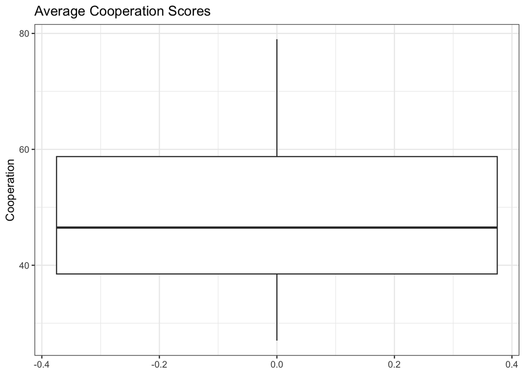

```r
ggplot(data = data, aes(y = cooperation)) +
  geom_boxplot() +
  theme_bw() +
  labs(title = "Average Cooperation Scores",
       y = "Cooperation")
```

Or I might want to plot a histogram. I used the additional geom, ‘geom_vline’ to plot a line representing the theorized population mean.

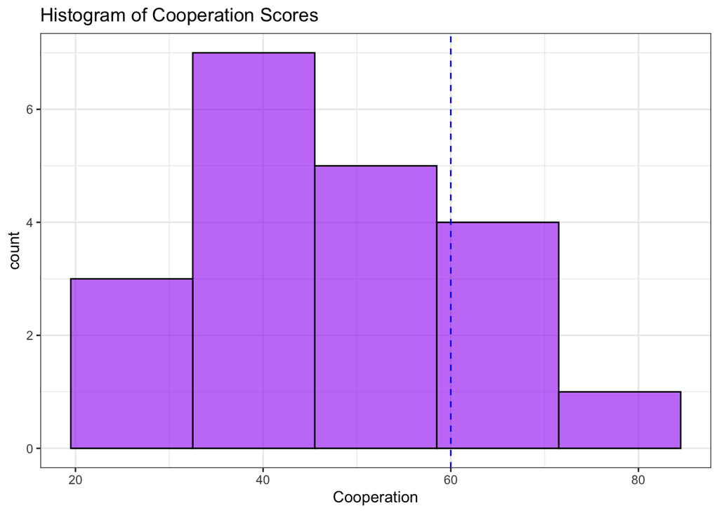

```r
ggplot(data = data) +
  geom_histogram(aes(x = cooperation), fill = "purple", color = "black", alpha = .6, bins = 5) +
  geom_vline(xintercept = 60, color = "blue", linetype = "dashed") +
  theme_bw() +
  labs(title = "Histogram of Cooperation Scores",
       x = "Cooperation")
```

# Paired-Sample *t*-test

To illustrate how paired-samples *t*-tests work, we are going to walk through [an example from your textbook](https://learningstatisticswithr-bookdown.netlify.com/ttest.html#pairedsamplesttest). In this example, the data comes from Dr. Chico’s introductory statistics class. Students in the class take two tests over the course of the semester. Dr. Chico gives notoriously difficult exams with the intention of motivating her students to work hard in the class and thus learn as much as possible. Dr. Chico’s theory is that the first test will serve as a “wake up call” for her students, such that when they realize how difficult the class actually is they will be motivated to study harder and earn a higher grade on the second test than they got on the first test.

You can load in the data from this example by running the following code:

```r
chico_wide <- import("https://raw.githubusercontent.com/uopsych/psy611/master/labs/resources/lab9/data/chico_wide.csv")

# long format
chico_long <- import("https://raw.githubusercontent.com/uopsych/psy611/master/labs/resources/lab9/data/chico_long.csv")
```

**Note:** You should now have 2 versions of the same data set loaded into your global environment. The only difference in these versions of the data is their “shape” – one is “wide” and the other is “long”. In the wide form, every row corresponds to a unique *person*; in the long form, every row corresponds to a unique *observation* or *measurement*.

- To get a sense of the differences between these two versions of the data, see below:

```r
chico_wide
```

```
##           id grade_test1 grade_test2
## 1   student1        42.9        44.6
## 2   student2        51.8        54.0
## 3   student3        71.7        72.3
## 4   student4        51.6        53.4
## 5   student5        63.5        63.8
## 6   student6        58.0        59.3
## 7   student7        59.8        60.8
## 8   student8        50.8        51.6
## 9   student9        62.5        64.3
## 10 student10        61.9        63.2
## 11 student11        50.4        51.8
## 12 student12        52.6        52.2
## 13 student13        63.0        63.0
## 14 student14        58.3        60.5
## 15 student15        53.3        57.1
## 16 student16        58.7        60.1
## 17 student17        50.1        51.7
## 18 student18        64.2        65.6
## 19 student19        57.4        58.3
## 20 student20        57.1        60.1
```

```r
chico_long
```

```
##           id  time grade
## 1   student1 test1  42.9
## 2   student2 test1  51.8
## 3   student3 test1  71.7
## 4   student4 test1  51.6
## 5   student5 test1  63.5
## 6   student6 test1  58.0
## 7   student7 test1  59.8
## 8   student8 test1  50.8
## 9   student9 test1  62.5
## 10 student10 test1  61.9
## 11 student11 test1  50.4
## 12 student12 test1  52.6
## 13 student13 test1  63.0
## 14 student14 test1  58.3
```

[output cut: 26 more lines]

We will work with both versions of this dataset today.

**Question:** What is a paired samples t-test?

**Question:** What are our null and alternative hypotheses?

**Question:** What are our assumptions?

### The null and alternative hypotheses

The null hypothesis states that..

$$H_{0}: \mu_{D} = 0$$

The alternative hypothesis states that..

$$H_{1}: \mu_{D} \neq 0$$

### Assumptions

The assumptions include..

1. *Normality*: Assume that the population distribution is normally distributed.
2. *Independence*: Assume that the participants are independent of one another.

### Sampling Distribution of Mean Difference Scores

For a paired samples t-test, the sampling distribution is a *t* distribution. It represents all the possible mean difference scores we could expect to obtain if we randomly obtained a sample of size *n* from the population that is described by the null hypothesis.

### The Paired Samples t-Statistic

$$t = \frac{\bar D}{\hat \sigma_{D} /
\sqrt{N}}$$

The t-statistic for the paired samples t-test takes the average difference score (the difference between two pairs of related scores), and divides by the estimated standard error of the sampling distribution.

## Paired Samples t-test

### Option 1: One-sample *t*-test of difference scores

One way to conduct a paired samples t-test in R is to use the `t.test()` function we used earlier, but the variable you give as an input is the *difference scores* between two conditions of related scores.

The example immediately below uses the `t.test()` function in the `{stats}` package to conduct the one-sample *t*-test of the difference scores.

```r
# First, construct a new variable of difference scores
chico_wide$diff <- chico_wide$grade_test2 - chico_wide$grade_test1

# Then, pass the difference scores to the t.test function
t.test(x = chico_wide$diff, mu = 0)
```

```
##
##  One Sample t-test
##
## data:  chico_wide$diff
## t = 6.4754, df = 19, p-value = 0.000003321
## alternative hypothesis: true mean is not equal to 0
## 95 percent confidence interval:
##  0.9508686 1.8591314
## sample estimates:
## mean of x
##     1.405
```

You could also use the `oneSampleTTest()` function from the `{lsr}` package to conduct the one-sample *t*-test of the difference scores.

```r
oneSampleTTest(x = chico_wide$diff, mu = 0)
```

```
##
##    One sample t-test
##
## Data variable:   chico_wide$diff
##
## Descriptive statistics:
##              diff
##    mean     1.405
##    std dev. 0.970
##
## Hypotheses:
##    null:        population mean equals 0
##    alternative: population mean not equal to 0
##
## Test results:
##    t-statistic:  6.475
##    degrees of freedom:  19
##    p-value:  <.001
##
## Other information:
##    two-sided 95% confidence interval:  [0.951, 1.859]
##    estimated effect size (Cohen's d):  1.448
```

## Option 2: Paired samples *t*-test

You can also conduct a paired samples t-test using the `t.test()` function with the raw scores from two related conditions if you set the argument `paired = TRUE`. The results will be exactly the same as running the one sample *t*-test on the difference scores.

```r
t.test(x = chico_wide$grade_test1,
       y = chico_wide$grade_test2,
       paired = TRUE)
```

```
##
##  Paired t-test
##
## data:  chico_wide$grade_test1 and chico_wide$grade_test2
## t = -6.4754, df = 19, p-value = 0.000003321
## alternative hypothesis: true mean difference is not equal to 0
## 95 percent confidence interval:
##  -1.8591314 -0.9508686
## sample estimates:
## mean difference
##          -1.405
```

Or you can use the `pairedSamplesTTest()` function from the `{lsr}` package.

```r
pairedSamplesTTest(formula = ~ grade_test2 + grade_test1, # one-sided formula
                   data = chico_wide) # wide format
```

```
##
##    Paired samples t-test
##
## Variables:  grade_test2 , grade_test1
##
## Descriptive statistics:
##             grade_test2 grade_test1 difference
##    mean          58.385      56.980      1.405
##    std dev.       6.406       6.616      0.970
##
## Hypotheses:
##    null:        population means equal for both measurements
##    alternative: different population means for each measurement
##
## Test results:
##    t-statistic:  6.475
##    degrees of freedom:  19
##    p-value:  <.001
##
## Other information:
##    two-sided 95% confidence interval:  [0.951, 1.859]
##    estimated effect size (Cohen's d):  1.448
```

### Long vs. wide format

Note that in the example above, using the `pairedSamplesTTest()` function, we used the wide format data. When using wide data with `pairedSamplesTTest()`, you enter a one-sided formula that contains your two repeated measures conditions (e.g. `~ grade_test2 + gradte_test1`).

The `pairedSamplesTTest()` function can also be used with long data. In this case, you must use a two-sided formula: `outcome ~ group`. You also need to specify the name of the ID variable. Note that the grouping variable must also be a factor.

```r
# grouping variable (time) must be a factor
chico_long <- chico_long %>%
  mutate(time = as.factor(time),
         id = as.factor(id))

pairedSamplesTTest(formula = grade ~ time, # two-sided formula
                   data = chico_long, # long format
                   id = "id") # name of the id variable
```

```
##
##    Paired samples t-test
##
## Outcome variable:   grade
## Grouping variable:  time
## ID variable:        id
##
## Descriptive statistics:
##              test1  test2 difference
##    mean     56.980 58.385     -1.405
##    std dev.  6.616  6.406      0.970
##
## Hypotheses:
##    null:        population means equal for both measurements
##    alternative: different population means for each measurement
##
## Test results:
##    t-statistic:  -6.475
##    degrees of freedom:  19
##    p-value:  <.001
##
## Other information:
##    two-sided 95% confidence interval:  [-1.859, -0.951]
##    estimated effect size (Cohen's d):  1.448
```

## Interpretation and Write-Up

```r
#First I'll run my t-test again, but this time I'll save it to a variable:
pairedtoutput  <- t.test(x = chico_wide$grade_test1,
                         y = chico_wide$grade_test2,
                         paired = TRUE)

#Let's look at our output options
apa_print(pairedtoutput)
```

```
## $estimate
## [1] "$M_D = -1.40$, 95\\% CI $[-1.86, -0.95]$"
##
## $statistic
## [1] "$t(19) = -6.48$, $p < .001$"
##
## $full_result
## [1] "$M_D = -1.40$, 95\\% CI $[-1.86, -0.95]$, $t(19) = -6.48$, $p < .001$"
##
## $table
## A data.frame with 5 labelled columns:
##
##   estimate       conf.int statistic df p.value
## 1    -1.40 [-1.86, -0.95]     -6.48 19  < .001
##
## estimate : $M_D$
## conf.int : 95\\% CI
## statistic: $t$
## df       : $\\mathit{df}$
## p.value  : $p$
## attr(,"class")
## [1] "apa_results" "list"
```

- Practice using the output from ‘apa_print’ to write your results here:

“Performance significantly improve from test 1 to test 2 ($M_D = -1.40$, 95% CI $[-1.86, -0.95]$, $t(19) = -6.48$, $p < .001$).

## Plotting paired-samples data

When plotting paired samples data, we want some way to clearly represent the repeated measures structure of the data. One way to do this is to draw a line between each pair of data points. This can be done with the `ggpaired()` function from `{ggpubr}`.

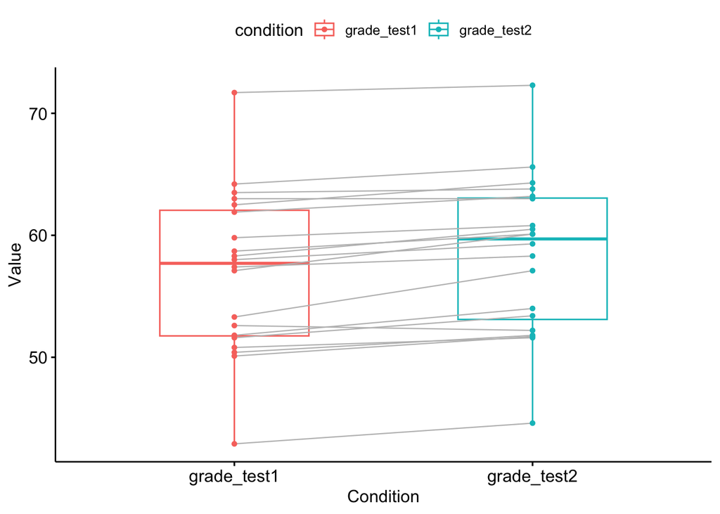

```r
# wide format
ggpaired(chico_wide,
         cond1      = "grade_test1", # first condition
         cond2      = "grade_test2", # second condition
         color      = "condition",
         line.color = "gray",
         line.size  = 0.4)
```

- If you want to make the plot with the long format of the data, you can do the following:

```r
# long format
ggpaired(chico_long,
         x          = "time", # grouping variable
         y          = "grade", # outcome variable
         color      = "time",
         line.color = "gray",
         line.size  = 0.4)
```

[output not shown]

# Minihacks

## Minihack 1:

You are developing a scale to quantify how delicious a food is. You design it such that 0 is as delicious as cement, 25 is delicious as an olive, and 50 is delicious as a strawberry. You aren’t sure exactly where pancakes should fall, but you’re interested in whether they differ from the deliciousness of strawberries. You order takeout pancakes from 17 local diners and score each.

Generate the data by running the the following code:

```r
# set seed for reproducibility
set.seed(42)

# load data
pancakes <- data.frame("id"      = 1:17,
                        "Delicious" =  rnorm(17, 55, 10))
```

1. Run an appropriate test based on your research question.

```r
#Your code here
pancake_analysis <- t.test(x = pancakes$Delicious, mu = 50)
pancake_analysis
```

```
##
##  One Sample t-test
##
## data:  pancakes$Delicious
## t = 3.996, df = 16, p-value = 0.001041
## alternative hypothesis: true mean is not equal to 50
## 95 percent confidence interval:
##  54.45060 64.50847
## sample estimates:
## mean of x
##  59.47953
```

```r
apa_print(pancake_analysis)
```

```
## $estimate
## [1] "$M = 59.48$, 95\\% CI $[54.45, 64.51]$"
##
## $statistic
## [1] "$t(16) = 4.00$, $p = .001$"
##
## $full_result
## [1] "$M = 59.48$, 95\\% CI $[54.45, 64.51]$, $t(16) = 4.00$, $p = .001$"
##
## $table
## A data.frame with 5 labelled columns:
##
##   estimate       conf.int statistic df p.value
## 1    59.48 [54.45, 64.51]      4.00 16    .001
##
## estimate : $M$
## conf.int : 95\\% CI
## statistic: $t$
## df       : $\\mathit{df}$
## p.value  : $p$
## attr(,"class")
## [1] "apa_results" "list"
```

```r
# or

oneSampleTTest(x = pancakes$Delicious, mu = 50)
```

```
##
##    One sample t-test
##
## Data variable:   pancakes$Delicious
##
## Descriptive statistics:
##             Delicious
##    mean        59.480
##    std dev.     9.781
##
## Hypotheses:
##    null:        population mean equals 50
##    alternative: population mean not equal to 50
##
## Test results:
##    t-statistic:  3.996
##    degrees of freedom:  16
##    p-value:  0.001
##
## Other information:
##    two-sided 95% confidence interval:  [54.451, 64.508]
##    estimated effect size (Cohen's d):  0.969
```

2. Report and interpret your results by filling in the embedded r code below.

We found that the average deliciousness of pancakes ($M = 59.48$, 95% CI $[54.45, 64.51]$) was significantly higher compared to strawberries, $t(16) = 4.00$, $p = .001$.

3. Plot a histogram of your data.

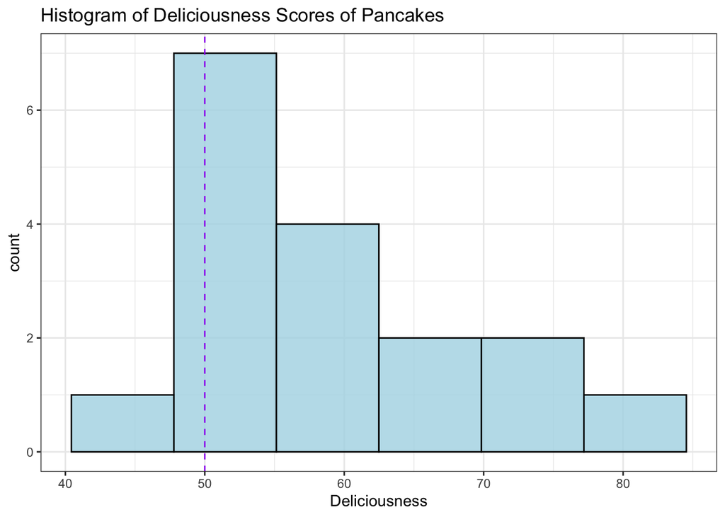

```r
#Your code here
ggplot(data = pancakes) +
  geom_histogram(aes(x = Delicious), fill = "light blue", color = "black", alpha = .8, bins = 6) +
  theme_bw() +
  geom_vline(xintercept = 50, color = "purple", linetype = "dashed") +
  labs(title = "Histogram of Deliciousness Scores of Pancakes",
       x = "Deliciousness")
```

## Minihack 2:

A clinical psychologist wants to know whether a new cognitive-behavioral therapy (CBT) program helps alleviate anxiety. He enrolls 12 individuals diagnosed with an anxiety disorder in a 6-week CBT program. Participants are given an Anxiety Scale before they begin and after they complete treatment.

Import the data by running the following code:

```r
cbt_data <- import("https://raw.githubusercontent.com/uopsych/psy611/master/labs/resources/lab9/data/cbt_data.csv")
```

1. Run a paired-samples *t*-test to determine whether participants’ anxiety scores changed from before to after the CBT treatment.

```r
#Your code here
cbt_data
```

```
##    id before after
## 1   1     10     5
## 2   2     12     6
## 3   3      8     7
## 4   4     12     8
## 5   5     15    10
## 6   6     18    11
## 7   7      6     3
## 8   8      5     4
## 9   9      6     6
## 10 10     10     7
## 11 11     12     8
## 12 12     15     9
```

```r
paired_t_results <- t.test(x = cbt_data$before,
       y = cbt_data$after,
       paired = TRUE)

# or

pairedSamplesTTest(formula = ~ before + after, # one-sided formula
                   data = cbt_data)
```

```
##
##    Paired samples t-test
##
## Variables:  before , after
##
## Descriptive statistics:
##             before after difference
##    mean     10.750 7.000      3.750
##    std dev.  4.048 2.374      2.221
##
## Hypotheses:
##    null:        population means equal for both measurements
##    alternative: different population means for each measurement
##
## Test results:
##    t-statistic:  5.849
##    degrees of freedom:  11
##    p-value:  <.001
##
## Other information:
##    two-sided 95% confidence interval:  [2.339, 5.161]
##    estimated effect size (Cohen's d):  1.689
```

2. Verify your results using a one sample t-test on difference scores

```r
#Your code here
cbt_data$diff <- cbt_data$after - cbt_data$before

t.test(x = cbt_data$diff, mu = 0)
```

```
##
##  One Sample t-test
##
## data:  cbt_data$diff
## t = -5.8495, df = 11, p-value = 0.000111
## alternative hypothesis: true mean is not equal to 0
## 95 percent confidence interval:
##  -5.16101 -2.33899
## sample estimates:
## mean of x
##     -3.75
```

```r
apa_print(paired_t_results)
```

```
## $estimate
## [1] "$M_D = 3.75$, 95\\% CI $[2.34, 5.16]$"
##
## $statistic
## [1] "$t(11) = 5.85$, $p < .001$"
##
## $full_result
## [1] "$M_D = 3.75$, 95\\% CI $[2.34, 5.16]$, $t(11) = 5.85$, $p < .001$"
##
## $table
## A data.frame with 5 labelled columns:
##
##   estimate     conf.int statistic df p.value
## 1     3.75 [2.34, 5.16]      5.85 11  < .001
##
## estimate : $M_D$
## conf.int : 95\\% CI
## statistic: $t$
## df       : $\\mathit{df}$
## p.value  : $p$
## attr(,"class")
## [1] "apa_results" "list"
```

3. Report and interpret your results using r code embedded in text.

There was a significant decrease in anxiety scores after CBT compared to before ($M_D = 3.75$, 95% CI $[2.34, 5.16]$), $t(11) = 5.85$, $p < .001$.

4. Obtain a table of descriptive statistics.

```r
#Your code here
describe(cbt_data)
```

```
##        vars  n  mean   sd median trimmed  mad min max range skew kurtosis   se
## id        1 12  6.50 3.61    6.5     6.5 4.45   1  12    11 0.00    -1.50 1.04
## before    2 12 10.75 4.05   11.0    10.6 5.19   5  18    13 0.14    -1.26 1.17
## after     3 12  7.00 2.37    7.0     7.0 2.22   3  11     8 0.00    -1.14 0.69
## diff      4 12 -3.75 2.22   -4.0    -3.8 2.22  -7   0     7 0.26    -1.35 0.64
```

4. Plot the data using `ggpaired()`.

```r
#Your code here
cbt_data
```

```
##    id before after diff
## 1   1     10     5   -5
## 2   2     12     6   -6
## 3   3      8     7   -1
## 4   4     12     8   -4
## 5   5     15    10   -5
## 6   6     18    11   -7
## 7   7      6     3   -3
## 8   8      5     4   -1
## 9   9      6     6    0
## 10 10     10     7   -3
## 11 11     12     8   -4
## 12 12     15     9   -6
```

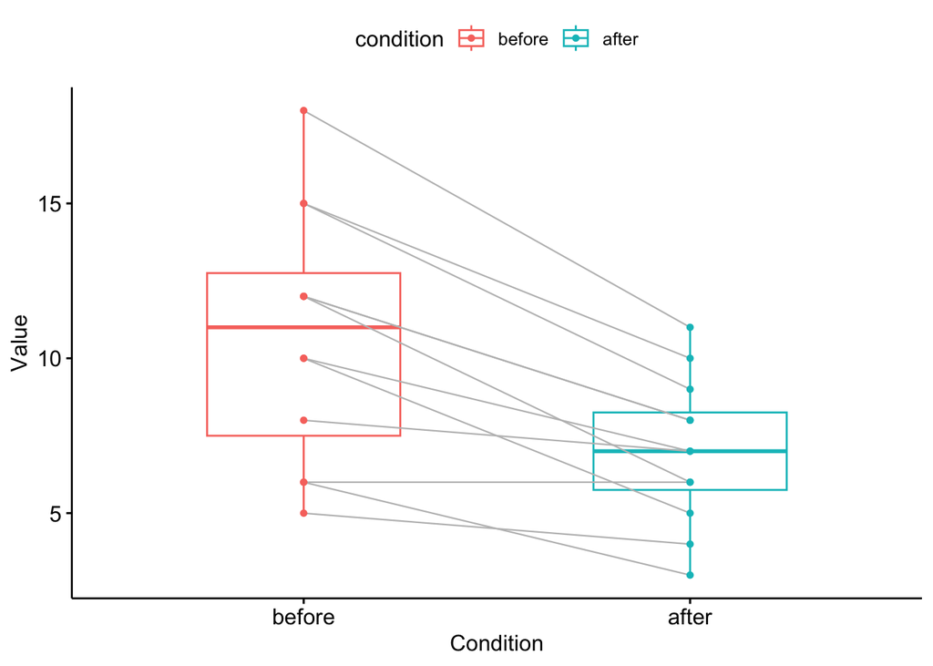

```r
ggpaired(cbt_data,
         cond1      = "before", # first condition
         cond2      = "after", # second condition
         color      = "condition",
         line.color = "gray",
         line.size  = 0.4)
```

5. **BONUS:** Recreate this same type of plot without using ggpaired

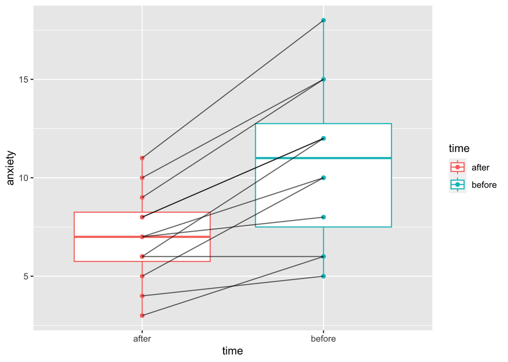

```r
#make into long format
cbt_data %>%
  gather(time, anxiety, 2:3)-> cbt_long

#basic version of plot
ggplot(cbt_long, aes(x=time, y=anxiety, color=time)) +
  geom_boxplot() +
  geom_point() +
  geom_line(aes(group=id),
            color='black',
            alpha=.6)
```